# Main Document

Author Name

Fri 17 Mar 2017

# Using this template

## Basics

```r
data(mtcars)
```

## Figures and Figure labels

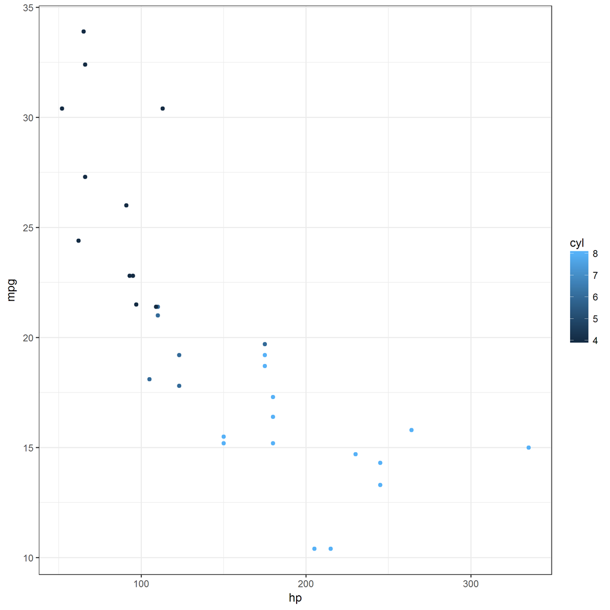

**Figure 1:** An example plot (Download as PDF)

[interactive chart not shown]

**Figure 1:** An example plot (Download as PDF)

Note that a figure label (by default this is *Figure N*) is added to the figure caption when the plot is included in the output. This plot can be referenced in the text by including a call to the `figRef` function using the the chunk label as its only argument. This is a reference to Figure 1. The *reportMD* package supports the use of interactive plots in HTML pages (generated with [*plotly*](https://github.com/ropensci/plotly)) as well static versions. This feature relies on the use of *ggplot2* for plotting. Using the *plotMD* function to produce the plot from a *grob* prepared earlier allows seamless switching between the two by setting the `fig_format` option, either globally (in the YAML frontmatter or in the call to *render*), via a call to `knitr::opts_chunk$set` or in the options for an individual chunk. Please note that the interactive version of a figure is only shown on devices with sufficient resolution. On low resolution screens (or in small browser windows) a static version of the plot will be displayed instead.

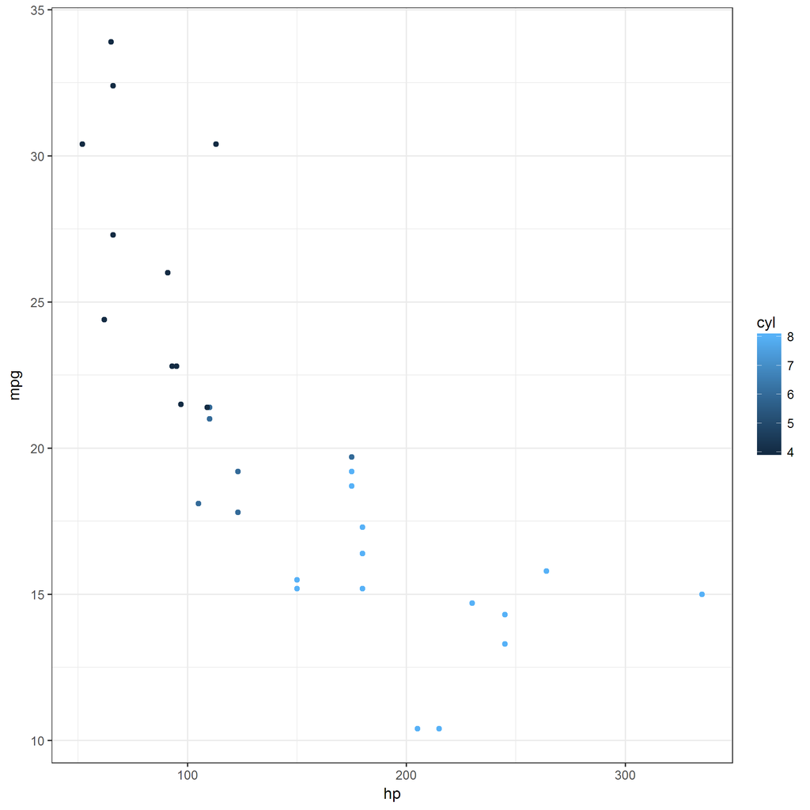

**Figure 2:** Static version of Figure 1 (Download as PDF)

### Controlling Figure size

The size of generated figures can be controlled via the *fig_width* and *fig_height* options. These work in the YAML header, where they will set the default size for all figures in the document, as well as in the options for an individual figure chunk. In either case *fig_width* and *fig_height* should be specified in inches.

By default the output document will display thumbnails of figures on screens that are at least 992px wide. The default for these thumbnails is to be half the width of the main text. To change the size of the thumbnails set *thumbnail_size* in the YAML header to a value between 1 and 12, where 12 corresponds to the width of the main text. The size of the thumbnail for an individual figure can be changed by setting the *bootstrap.thumbnail.size* chunk option. To disable thumbnails entirely, set `thumbnail: false` in the YAML header or `bootstrap.thumbnail=FALSE` in the chunk options.

### Appearance of Figure lables

A number of options are available to modify the appearance of figure lables. The default appearance (**Figure N**: Some caption) can be changed by setting the *figcap_prefix*, *figcap_sep* and *figcap_prefix_highlight* options in the YAML header. These control the prefix (‘Figure’), separator (‘:’) and highlighting (**bold**) of the figure label respectively. For example, to change figure labels to the form ‘*Fig. N:*’, set *figcap_prefix* to ‘Fig.’ and *figcap_prefix_highlight* to ’*’.

## Tables

Tables can be added to the output document by printing a `data.frame` or `matrix` using *printMD*. Use the `tab.cap` chunk option to provide a table caption.

**Table 1:** A subset of the *mtcars* dataset (download).

|  | mpg | hp | cyl |
| --- | --- | --- | --- |
| **Mazda RX4** | 21 | 110 | 6 |
| **Mazda RX4 Wag** | 21 | 110 | 6 |
| **Datsun 710** | 22.8 | 93 | 4 |
| **Hornet 4 Drive** | 21.4 | 110 | 6 |
| **Hornet Sportabout** | 18.7 | 175 | 8 |

It sometimes is desirable to provide access to the data displayed in the table. If a table chunk contains an option of the form `download="variable_name"`, a file containing the the data stored in *variable_name* will be created and a download link pointing to that file will be added to the table caption.

Tables can be referenced in the same way as figures, using the *tabRef* function. This is a reference to Table 1.

## Using R objects from child documents

Your R chunks may use objects created by a chunk in a different (child) document, provided the generating chunk is cached and the cache is available when this document is knitted. To do this, simply list the path to the child document in the YAML header under the output options:

```yaml
output:
  reportMD::multi_document:
    depends:
      part1: part1.Rmd
      part2: part2.Rmd
```

This will load all R objects generated by cached chunks in *part1.Rmd* into the environment in which the chunks of this document are evaluated. To only load a subset of chunks from the child document, provide a list of chunk labels:

```yaml
output:
  reportMD::multi_document:
    depends:
      part2:
        part2.Rmd: [regression, prepRegPlot]
```

Sometimes it may be preferable not to load R objects from other documents directly into the global environment. To load dependencies into a separate environment for each child document, add the `use_namespace` option:

```yaml
output:
  reportMD::multi_document:
    depends:
      part2:
        part2.Rmd: [regression, prepRegPlot]
    use_namespace: true
```

Now objects form *part2.Rmd* are accessible as `part2$object_name` (instead of simply `object_name`). This helps to avoid name clashes between objects imported from different documents.

Eiter way, we have direct access to the R objects created in the child documents and can use them in the main document in whatever order is most useful to explain the analysis and discuss the results. In *part2.Rmd* we constructed a ggplot and cached the resulting object. This can now be used to produce the plot here (Figure 3).

Note that some care is necessary when reproducing plots from child documents. If the plot is not self contained, i.e. it references local variables from the envirnment where it was created, the chunks containing the relevant variables have to be specified as dependencies. If *use_namespace* is set it is also necessary to provide the environment corresponding to the child document to *plotMD*.

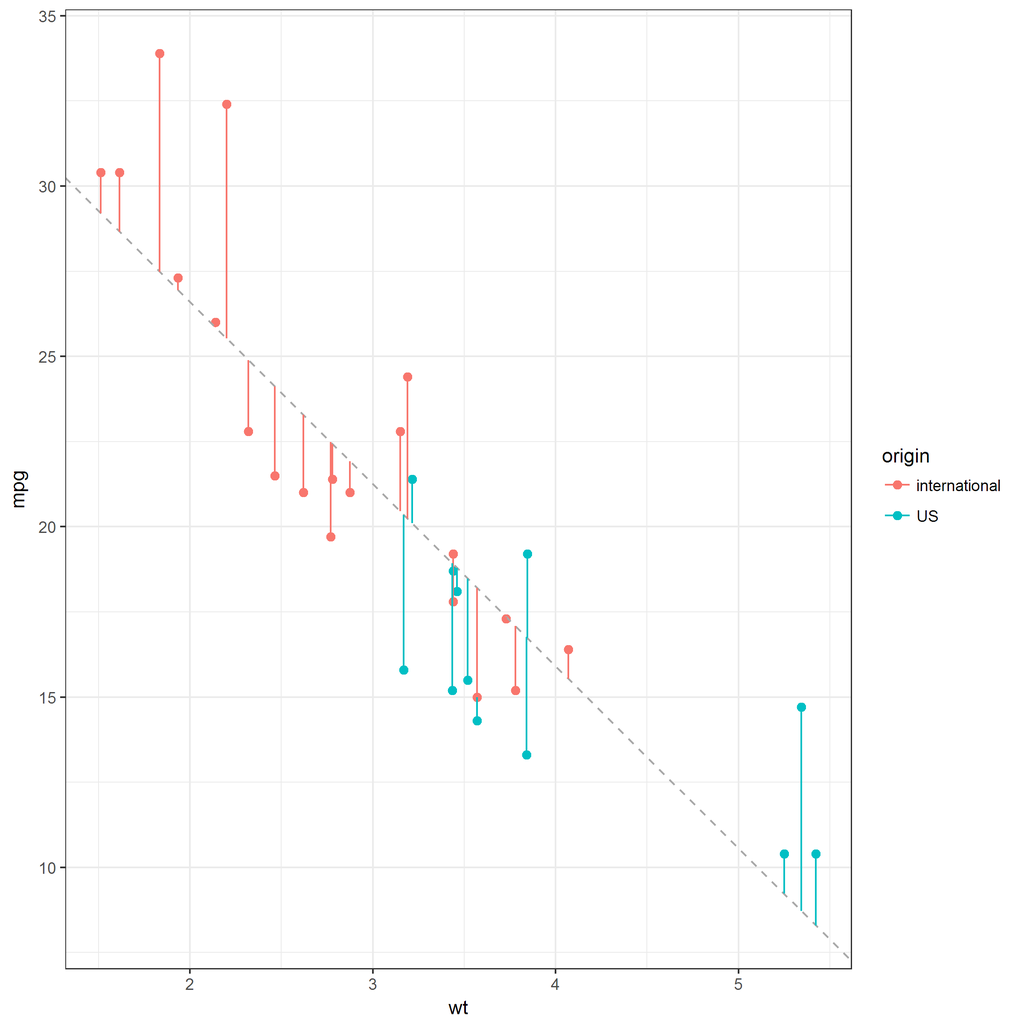

**Figure 3:** Linear regression result. Car weight is a good predictor for MPG and the US built cars in the dataset tend to be heavier. (Download as PDF)

```r
plotMD(part2$reg_fig, envir=part2)
```

In addition to specifying all chunks to import from a child document it is also possible to specify required chunks as part of the *dependson* chunk option by providing dependencies of the form ‘`child label`:`chunk label`’. For example, to load the *regression* chunk from *part2.Rmd* (to which we have assigned the label *part2*) we could add `dependson='part2:regression'` to the chunk options. This has the advantage that dependencies are managed for each chunk, making it easier to update dependencies as the requirements of a code chunk change. It also makes it more explicit where objects in a code chunk come from.

## Linking to child documents

It may be useful to add links to the child documents in appropriate places throughout the text. This can be achieved using *pandoc*’s reference link syntax. For example, to link to Part 2 simply use `[some text][part2]`. Links to all document dependencies listed in the header will be added to the *Related Documents* section of the appendix.

It is possible to link to specific parts of a child document by using the corresponding dependency object directly.

```r
deps <- knitr::opts_knit$get('dependencies')
```

Printing a dependency object (*via* `printMD`) will insert a reference to the corresponding output document in the text. The optional `target` argument to `printMD` allows to specify any anchor for the link. This can correspond to a heading, e.g. see the Introduction of Part 1, or a code chunk (details of the regression model used in Part 2).

It is also possible to link to a figure or table in a child document by providing the corresponding label from the list of dependencies to indicate the target file: Part 2, Figure 1.

# Appendix

## Custom Functions

```r
## Custom functions used in the analysis should go into this chunk.
## They will be listed in their own section of the appendix.
```

## Configuration

```r
## This chunk should contain global configuration commands.
## Use this to set knitr options and related things. Everything
## in this chunk will be included in an appendix to document the
## configuration used.

## Pander options
panderOptions("digits", 3)
panderOptions("table.split.table", 160)
```

## Version

### Document version

Fri Mar 17 13:48:12 2017

## Downloads

| File | Description |
| --- | --- |
| Table 1 | A subset of the *mtcars* dataset. |

## Related Documents

Part 1  
Part 2

Created with reportMD